# Mathematical Optimisation 2021/2022 Vehicle rounting problem with load dependent travel times VRPLTT

23/6/2022

## Definizione del problema - VRP vs VRPLTT

Il problema da noi analizzato è una variante del noto problema **Vehicle Routing Problem** (VRP), definito come **Vehicle Routing Problem with Load dependent Travel Times** (VRPLTT).

Dato un insieme di nodi da visitare, il **VRP** minimizza il tempo di viaggio su un certo grafo e trova un insieme di *subtour* che permette di soddisfare la visita su tutti i nodi. Il valore della funzione obiettivo non tiene quindi conto della richiesta dei nodi ed il costo di percorrenza degli archi tra i nodi è costante. Il modello matematico a base del **VRPLTT** considera un costo di percorrenza degli archi variabile.

## Definizione del problema - VRPLTT

Il **VRP**, nel campo della logistica, viene utilizzato per programmare consegne minimizzando il tempo di viaggio dei corrieri.

Se il veicolo è un camion o un furgone, è quindi ragionevole l’ipotesi di velocità di percorrenza constante tra due nodi, anche al variare del carico trasportato. Nelle città alcuni vettori utilizzano mezzi alternativi come bici elettriche, per le quali il carico trasportato è un vincolo non trascurabile e dal quale dipende la velocità di percorrenza dell’arco.

## Armadillo

[figure not shown]

Il veicolo che abbiamo utilizzato per ricavare i parametri da inserire nel modello è l’ **Armadillo**, usato attualmente da DHL e noto come **Cubycycle**

Caratteristiche:

- Peso a vuoto: \(60 \space kg\)
- Carico massimo trasportabile: \([150,200] \space kg\)
- Potenza motore elettrico: \(250 \space W\) sotto i \(25 km/h\)

## Armadillo - Peso e Potenza

**Peso**:

**Potenza**:

- Un ciclista ben allenato può sviluppare fino \(150 \space W\) di potenza massima, e \(100 \space W\) di potenza continuativa. Sommati ai \(250 \space W\) del motore elettrico, se la velocità è inferiore a \(25 km/h\), la potenza massima a disposizione è quindi \(400 \space W\). Nel caso in cui la velocità superi i \(25 km/h\), la potenza massima disponibile è pari a quella del ciclista.

## Modello di velocità - 1

Il modello da noi utilizzato per calcolare la velocità, tiene conto della forza aerodinamica \(F_D\), della resistenza data dall’attrito di rotolamento \(F_R\), della forza di gravità \(F_G\) e delle forze di attrito delle parti meccaniche, modellizzate tramite il rendimento meccanico \(\eta\)

- \(F_D=\frac{\rho C_D Av^2}{2}\)
- \(F_R=C_R \cdot m \cdot g \cdot cos(tan^{-1}(h))\)
- \(F_G=m\cdot g \cdot sin(tan^{-1}(h))\)

All’equilibrio quindi consideriamo:

\(\eta P_{traction}=v({F_D+F_R+F_G})\)

Altro parametro fondamentale del problema sarà il gradiente \(h\), funzione del dislivello tra nodi e della loro distanza.

## Modello di velocità - 2

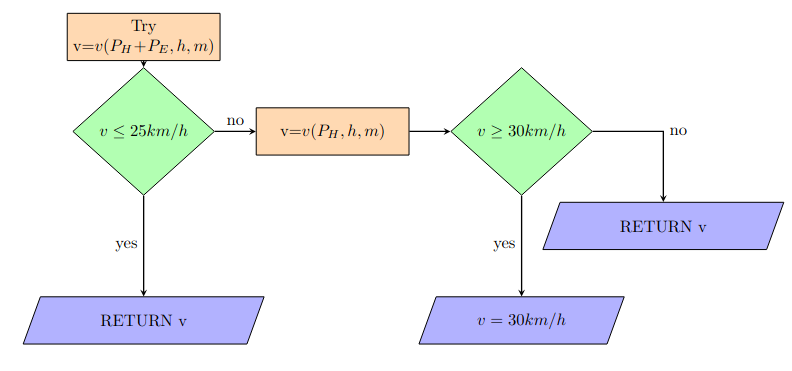

Il modello di velocità implementato, rispetto a quello descritto nell’articolo, è stato migliorato, introducendo vincoli sulla velocità massima raggiungibile. Il modello indicato dal paper permette velocità teoriche anche superiori a \(100 km/h\), in quanto la velocità risultante non considera i transitori, ma solo la condizione all’equilibrio.

## Formulazione matematica - Grafo

Il problema è definito su un grafo \(G=(N,E)\).

\(N=\{0..n\}\) rappresenta l’insieme dei nodi. Il nodo \(0\) è il deposito.

\(E\) rappresenta l’insieme degli archi \((i,j)\space \forall i,j\in N\).

Ogni arco \((i,j)\) ha un costo di percorrenza associato, ovvero il tempo di percorrenza dello stesso, funzione della distanza tra il nodo \(i\) e \(j\), del dislivello tra i due nodi e in fine del peso del veicolo nel momento di percorrenza.

## Formulazione matematica

Variabili decisionali binarie

Viene naturale definire la variabile decisionale binaria \(x_{ij}\).

\[x_{ij}= \begin{equation} \begin{cases} 1 \space se \space (i,j) \space viene\space percorso\\ 0 \space altrimenti \end{cases}\,. \end{equation} \]

**Livelli di carico**:

Per considerare il carico del veicolo, si introduce una discretizzazione dei possibili valori assunti dalla massa trasportata. Definiamo \(L\) l’insieme dei livelli di carico. Ogni livello di carico corrisponde all’intervallo \([p^l,r^l]\). Dove \(p^1=0\) e \(r^l=Q\), \(Q\) indica il carico massimo trasportabile (nel caso in esame \(Q\in[150,200]\)). Al variare di \(l\) otteniamo una discretizzazione più o meno accurata.

Il problema è quindi supportato da un insieme di \(l\) grafi, che differiscono per il solo costo di percorrenza degli archi, indicando \(t_{ij}^l\) il tempo di percorrenza dell’arco \((i,j)\) con un peso compreso tra \([p^l,r^l]\) (livello di carico pari a \(l\)). Il valore di riferimento per il calcolo della velocità sarà \(\frac{r^l+p^l}{2}\).

In fine indichiamo \(z_{ij}^l\) la variabile decisionale binaria tale che :

\[z_{ij}^l= \begin{equation} \begin{cases} 1 \space se \space (i,j) \space viene\space percorso \space con \space livello \space di \space carico \space l\\ 0 \space altrimenti \end{cases}\,. \end{equation} \]

## Formulazione matematica

Variabili decisionali continue

Infine introduciamo la variabile decisionale continua \(f_{ij} \geq 0\), che rappresenta il peso del veicolo nel percorrere l’arco \((i,j)\) .

Oltre al carico, è richiesta una specifica finestra temporale per la consegna, quindi indichiamo \(y_{i}\geq 0\) il tempo di consegna nel nodo \(i\).

## Formulazione matematica

Funzione obiettivo

La funzione obiettivo sarà quindi: \[min\sum_{i,j\in E}\sum_{l\in L}t_{ij}^lz_{ij}^l\]

Per calcolare \(t_{ij}^l\) usiamo un grafo \(\dot G^l\), che chiameremo **esteso** e comprenderà una serie di *nodi intermedi* posti sugli edge \((i,j)\in E\).

In questo modo il percorso tra vari clienti può essere spezzato in segmenti, idealmente ogni qual volta si ha un cambiamento di gradiente. Questo comporta un calcolo più accurato del tempo di percorrenza di un edge per ogni livello di carico.

Il percorso (quindi tempo di percorrenza \(t_{ij}^l\)) tra \(i\) e \(j\), per un dato valore di \(l\), quindi deve essere calcolato utilizzando un qualsiasi algoritmo per risolvere uno shortest path. La nostra implementazione utilizza Dijkstra, visto il valore strettamente positivo dei tempi di percorrenza.

## Formulazione matematica

Vincoli

\[\sum_{j \in N}x_{ij}=1 \quad \forall i \in N_0\] \[\sum_{i \in N}x_{ij}=1 \quad \forall j \in N_0\] La coppia di vincoli sopra indica che ogni nodo deve essere visitato esattamente una sola volta. L’insieme \(N_0\) rappresenta l’insieme dei nodi, escluso il deposito. Ne consegue che è possibile effettuare subtour, il veicolo può tornare al deposito e caricare nuovamente le merci.

## Formulazione matematica

Vincoli \[\sum_{j \in N}f_{ji}-\sum_{j \in N}f_{ij}=q_i \quad \forall i \in N_0\] Questo vincolo assicura che la richiesta \(q_i\) (il peso della merce da scaricare nel nodo \(i\)esimo) sia soddisfatta. E’ naturalmente definito per tutti nodi, ad eccezione del deposito.

## Formulazione matematica

Vincoli \[ q_j x_{ij} \leq f_{ij} \leq (Q-q_i)x_{ij} \quad \forall(i,j) \in E \] Il precedente vincolo assicura che il peso del veicolo \(f_{ij}\) sia limitato rispetto al livello di massimo carico meno il peso della merce scaricata nel nodo \(i\) e che sia sufficiente a soddisfare la richiesta del nodo \(j\).

## Formulazione matematica

Vincoli \[ \sum_{l \in L} z_{ij}^l = x_{ij} \quad \forall (i,j) \in E \] Stabiliamo la relazione tra le variabili decisionali, indicando che un arco va percorso solamente una volta ed a un determinato livello di carico.

## Formulazione matematica

Vincoli

\[ \sum_{l \in L}p^lz^l_{ij} \leq f_{ij} \leq \sum_{l \in L} r^l z^l_{ij} \quad \forall (i,j) \in E \]

Con la precedente relazione indichiamo un vincolo tra la variabile decisionale \(z_{ij}^l\) e \(f_{ij}\), di conseguenza con le richieste \(q_i\) dei nodi.

## Formulazione matematica

\[\quad {y_i-y_j+s_i+\sum_{l \in L} t_{ij}^lz_{ij}^l \leq M_{ij}(1-x_{ij}) \quad \forall i \in N, j \in N_0, i \neq j }\]

Dove:

\(M_{ij} = max \{0, b_i + s_i + t^{|L|}_{ij} - a_j \}\)

Osservazioni:

- Se \(x_{ij}=1\), il membro destro è nullo e quindi è implicito che il tempo di visita del nodo \(i\) più il tempo \(s_i\) ed il tempo di viaggio \(\sum_{l \in L} t_{ij}^lz_{ij}^l\) sia minore o uguale del tempo di visita di \(j\)
- Se \(x_{ij}=0\), vale la relazione \(y_i-y_j+s_i\leq max \{0, b_i + s_i + t^{|L|}_{ij} - a_j \}\)

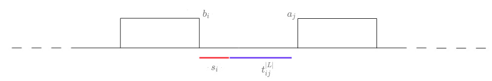

## Formulazione matematica

Vincoli \[a_i \leq y_i \leq b_i \quad \forall i \in N_0\] Ogni nodo inoltre ha una finestra di temporale \([a_i,b_i]\) cje deve essere rispettata per la consegna.

## Pipeline

Una volta implementato il modello tramite l’interfaccia python di Gurobi, si è resa necessaria la realizzazione di un **pipeline** di *preprocessing/sintesi* degli **input** e *postprocessing* degli **output**.

**Input:**

A corredo dell’articolo è presente un [repository GitHub](https://github.com/FontainePirmin/vrpltt/tree/main/instances) contentente alcuni .csv, realizzati tramite le API di google maps, rappresentanti casi verosimili. Su ispirazione di queste istanze è stato realizzato un generatore di dati sintetici dove i customer vengono posizionati in una griglia tridimensionale,con associata una richiesta \(q_i\) ed un intervallo di tempo \([a_i,b_i]\) .

In aggiunta ai dati generati dagli autori dell’articolo, nelle nostre instanze vengono inclusi i **nodi intermedi** ai customer, necessari per generare i grafi estesi \(\dot G^l\) descritti precedentemente.

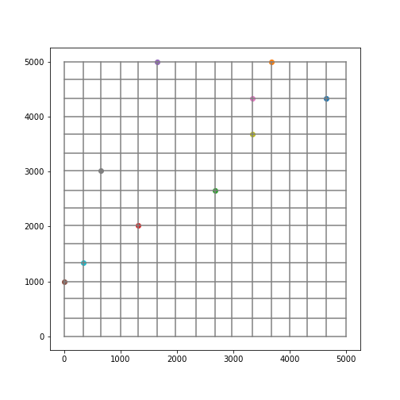

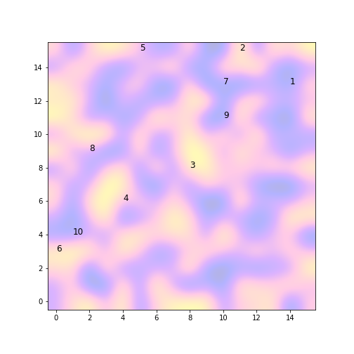

## Preprocessing dei dati - 1

Come già introdotto, prima di passare alla soluzione vera e propria del problema, è necessario un preprocessing dei *grafi estesi* \(\dot G^l\), ottenendo tra ogni coppia di nodi \((i,j)\) il tempo di percorrenza per ogni \(l\in L\). Una volta ottenuti i tempi di percorrenza di ogni arco è necessario trovare il tempo di percorrenza per ogni \((i,j)\in N\), quindi solo per i customer, escludendo i nodi intermedi. Per risolvere lo shortest path è stato utilizzato Dijkstra, ottenendo in fine \(t_{ij}^l\), tempo di percorrenza migliore tra \(i\) e \(j\). Tanti più punti intermedi vengono inclusi tra customer e tanto più accurata sarà la soluzione.

**Attenzione**:

- Il numero di variabili e vincoli non è funzione del numero di punti intermedi tra customer. Dopo la fase di preprocessing i punti intermedi e i reali percorsi saranno totalmente trasparenti.
- Se \(z_{ij}^l=1\) (e di conseguenza \(x_{ij}=1\)), **non** significa che viene percorso l’arco \((i,j)\) del grafo non esteso \(G^l\), ma che il nodo \(j\) è visitato immediatamente dopo il nodo \(i\). Per ottenere il percorso reale tra \(i\) e \(j\) è necessario controllare il percorso processato da Dijkstra nel grafo esteso \(\dot G^l\). È fondamentale scegliere il corretto \(l\), in quanto per livelli di carico differenti, il percorso migliore può essere differente.

## Preprocessing dei dati - 2

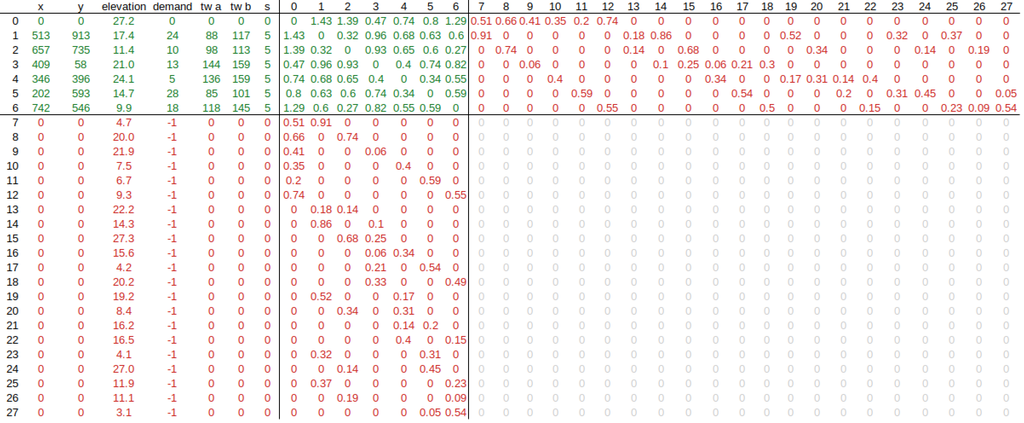

L’estratto sopra rappresenta tutti gli ingredienti necessari a risolvere il VRPLTT. Nello specifico il riquadro in alto a sinistra della tabella rappresenta il grafo ristretto \(G=(N,E)\), mentre l’intera tabella comprende anche i nodi intermedi ai customer (e deposito).

Osservando la matrice delle distanze possiamo individuare 4 blocchi:

- La sezione in alto a sinistra della matrice delle distanze è densa, quadrata e con diagonale nulla. Rappresenta la distanza tra i vari customer \(N\)
- Il blocco in alto a destra e in basso a sinistra sono sparsi, essendo ogni nodo intermedio mediamente connesso con soli due customer (nel caso di incroci può essere comune a più customer).
- Non essendo presenti edge tra nodi intermedi e nodi intermedi, il blocco in basso a destra è nullo (nel caso di un solo punto intermedio per ogni coppia customer).

## Postprocessing della soluzione

Una volta trovata la soluzione ottimale, per comodità di visualizzazione costruiamo un grafo che rappresenti tutti i subtour. Nel caso di dati *reali* e *non sintetici*, tramite le API di google maps è possibile anche visualizzare i risultati.

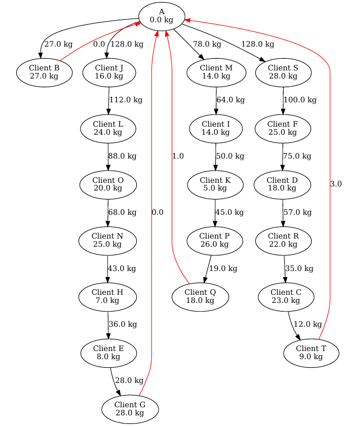

[figure not shown]

Fukuoka, Giappone

## Esperimenti numerici

Per esplorare il problema abbiamo sintentizzato dati e selezionato istanze mirate ad analizzare:

## Scalabilità - 1

La dimensione del problema in termini di numero di variabili e numero di vincoli dipende dal numero di customer e dal numero di livello di carico. La dipendenza del numero di variabili continue e binarie rispetto al numero di customer \(|N|\) è quadratica. Per quanto riguarda invece il numero di livelli di carico \(|L|\) abbiamo una dipendenza lineare delle variabili binarie, mentre le variabili continue non sono influenzate.

Le variabili decisionali hanno dimensioni:

- \(f_{ij} \in R_+^{|N|\times |N|}\)
- \(y_{j} \in R_+^{|N|}\)
- \(z_{ij}^l \in \{0,1\}^{|N|\times |N| \times |L|}\)
- \(x_{ij} \in \{0,1\}^{|N|\times |N|}\)

Come già scritto il numero di nodi intermedi non compare nella formulazione del problema e non influisce sul numero di vincoli e variabili, ma impatta il tempo di preprocessing, cambiando la il tempo di esecuzione dello shortest path risolto con Dijkstra.

## Scalabilità - 2

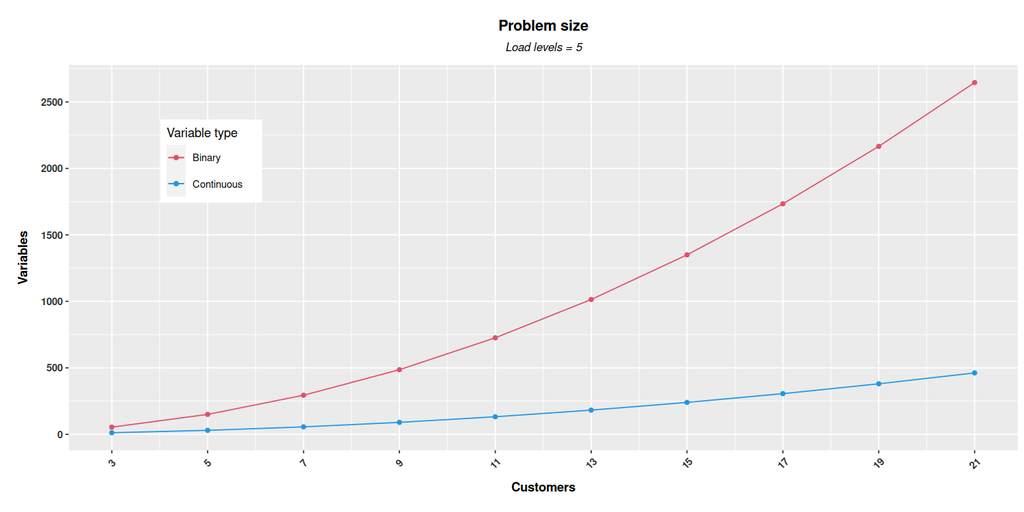

Dipendenza del numero di variabili rispetto il numero di customer.

## Scalabilità - 3

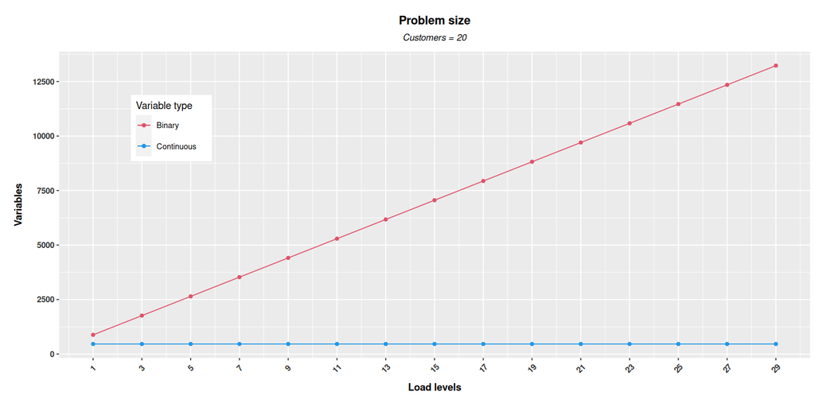

Dipendenza del numero di variabili rispetto il numero di livelli di carico.

## Scalabilità - 4

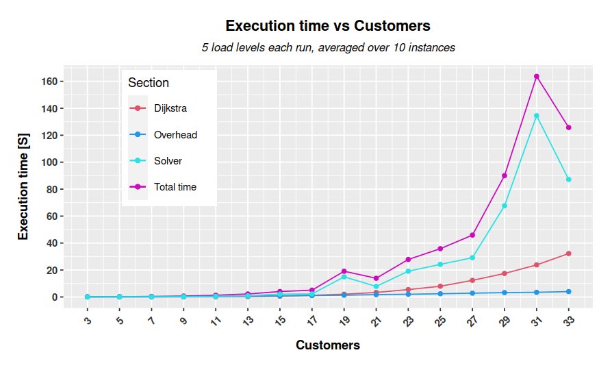

Dipendenza del tempo di esecuzione rispetto il numero di customer.

## Scalabilità - 5

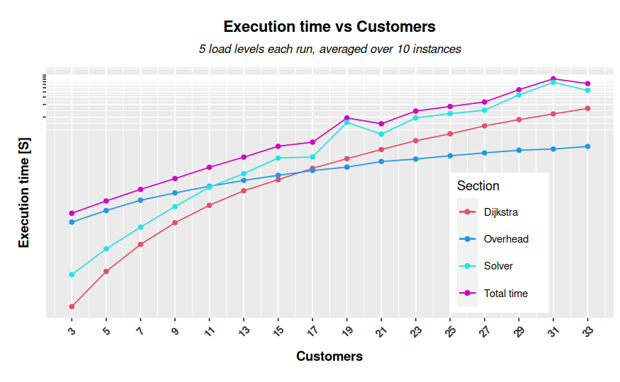

Dipendenza del tempo di esecuzione rispetto il numero di customer.

## Scalabilità - 6

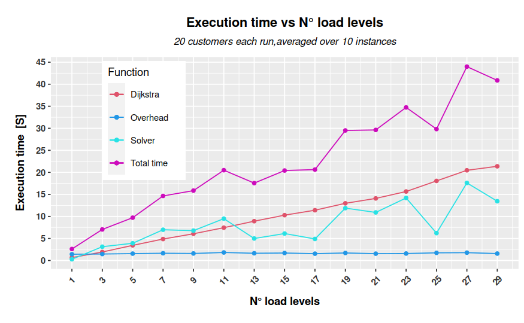

Dipendenza del tempo di esecuzione rispetto il numero di livelli di carico.

## Parametri: Potenza - 1

Al variare della quota di potenza del ciclista è ragionevole che il modello restituisca un valore della funzione obiettivo minore. I valori utilizzati sono \([75,150,300,450] W\). I load level disponibili sono \(5\) e i customer sono \(20\).

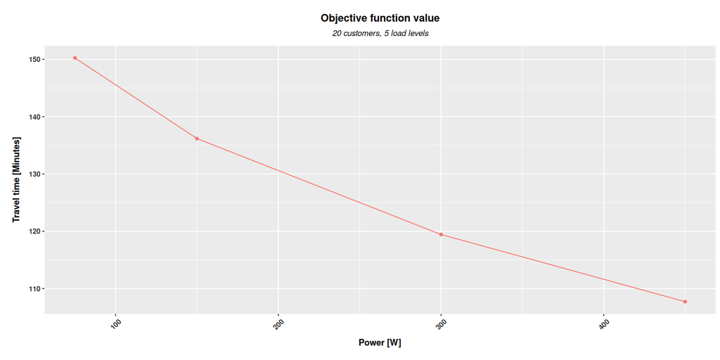

## Parametri: Potenza - 2

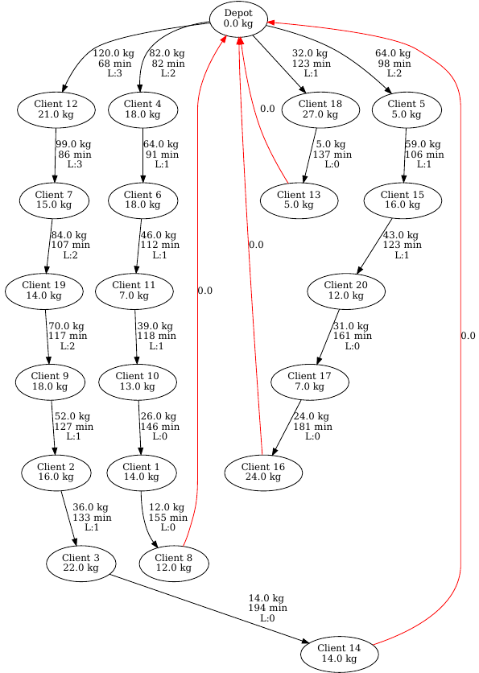

\(C_{low}=75W\)

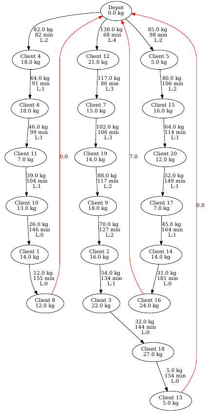

\(C_{high}=450W\)

\(C_{high}\) riesce a portare a termine le consegne effettuando 3 subtour contro i 4 di \(C_{low}\).

\(C_{low}\) percorre tutti gli archi con un livello di carico massimo pari a \(3\), nonostante \(|L|=5\), \(C_{high}\) invece percorre alcuni archi con un livello di carico superiore.

## Nodi intermedi - 1

Utilizzando dati da noi sintetizzati, abbiamo confrontato il valore della funzione obiettivo variando la fase di preprocessing, ovvero considerando o meno dei nodi intermedi tra i vari customer.

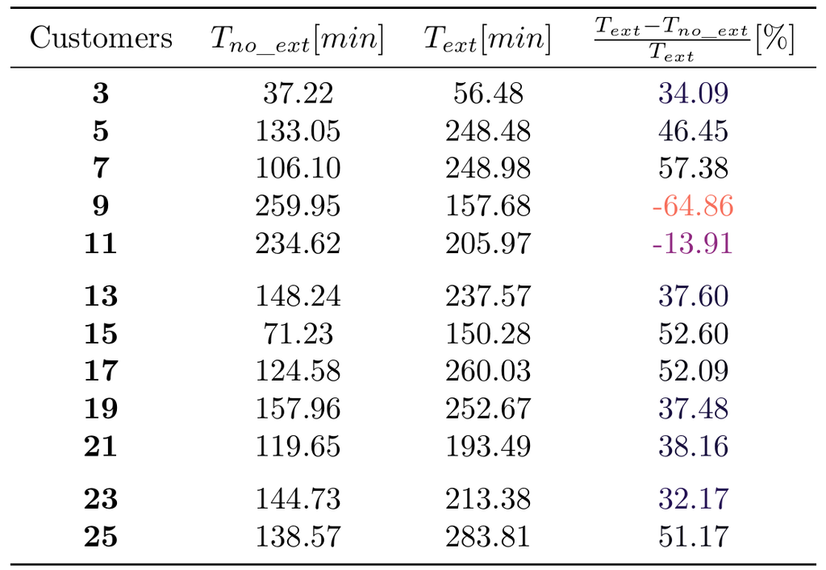

La tabella mostra come l’approssimazione di calcolo del gradiente porti a valori della funzione obiettivo molto distanti rispetto a quelli esatti comprendenti i punti intermedi. Spesso l’approssimazione tende a sottostimare il tempo di percorrenza.

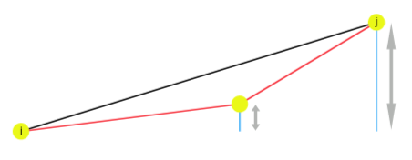

## Nodi intermedi - 2

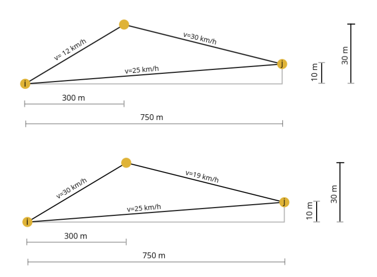

Nei casi illustrati a lato, i tempi di percorrenza senza punti intermedi sono:

- \(t_{ij}=108 \space s\)
- \(t_{ji}=108\space s\)

Mentre aggiungendo i punti intermedi otteniamo:

- \(t_{ij}=143\space s\)
- \(t_{ji}=119\space s\)

La massa utilizzata è pari a \(100kg\) e la potenza è \(150W\)

## Nodi intermedi - 3

Come già dimostrato, la dimensione del problema in termine di numero di variabili e vincoli non è influenzata dalla presenza dei nodi intermedi ma, nella fase di preprocessing il tempo di esecuzione dello shortest path è naturalmente penalizzato. Le simulazioni includono 5 livelli di carico e fino a 25 customer.

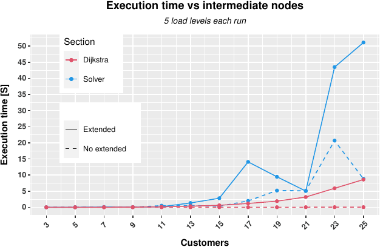

## Time window - 1

Ogni customer ha un intervallo temporale in cui deve essere visitato, rappresentato dai valori \([a_i,b_i]\). È interessante studiare il valore della funzione obiettivo nel caso di finestre temporali casuali, rispetto ad un’unica finestra temporale comune a tutti i customer. Quest’ultimo caso può essere visto come un rilasssamento dei vincoli del problema originale, in quanto il vincolo temporale non è più significativo.

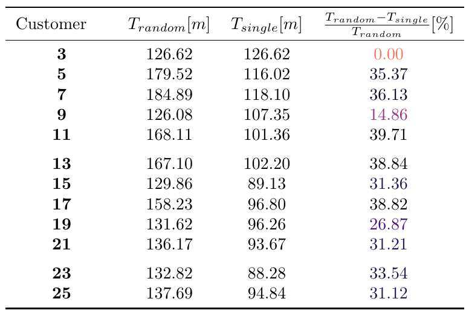

Il valore della funzione obiettivo è migliore in caso di una singola finestra temporale. Probabilmente un set di subtour ottimale dal punto di vista temporale non può soddisfare i vincoli sull’intervallo di consegna.

## Time window - 2

La dimensione del problema in termini di variabili e vincoli rimane comunque invariata, ma osserviamo come per questa particolare istanza, il tempo di soluzione sia maggiore nel caso di una singola finestra temporale.

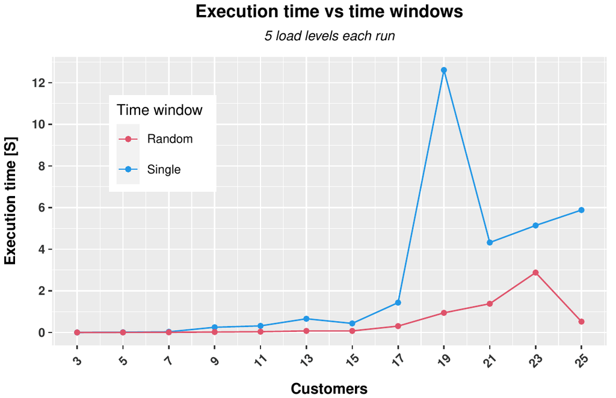

È possibile spiegare il risultato come un numero minore di possibili nodi da esplorare, visto il numero sicuramente più grande di soluzioni infeasible con finestre temporali casuali.

## Peso

Abbiamo indagato come il valore della funzione obiettivo e i subtour generati varino in funzione della richiesta dei customer. Abbiamo utilizzato le istanze generate dagli autori dell’articolo, che includono:

- 2 scenari con peso medio \(18kg\)
- 2 scenari con peso medio \(36kg\)
- 2 scenari con peso medio \(45kg\)

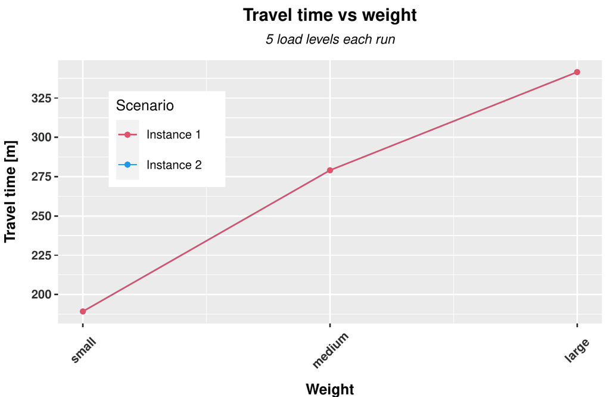

## Peso - 18kg

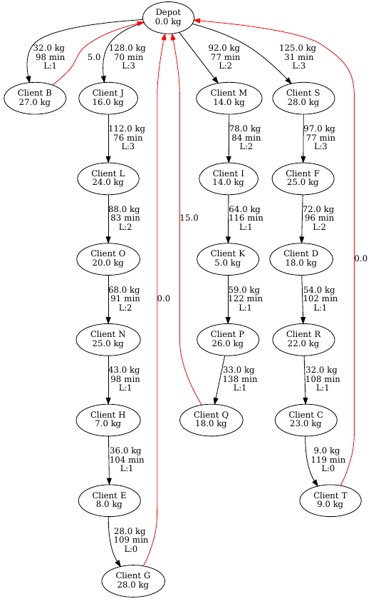

[figure not shown]

Fukuoka, Giappone

## Peso - 36 kg

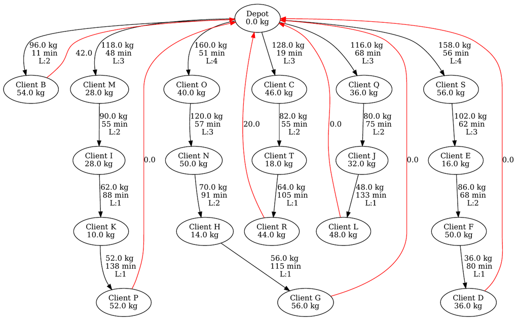

## Peso - 45 kg

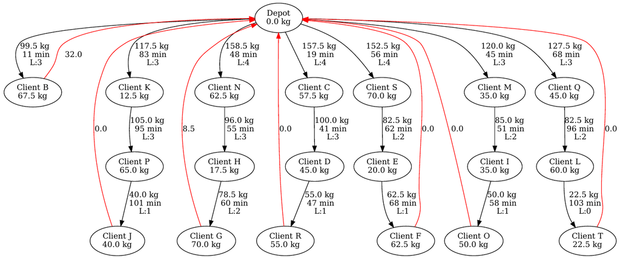

## Numero di livelli di carico - 1

Il numero di livelli di carico rappresenta la bontà della discretizzazione dei valori di peso del veicolo. All’aumentare del numero di livelli di carico, aumenta la plausibilità del valore della funzione obiettivo. Un solo livello di carico nelle istanze da noi analizzate, tende a sottostimare il tempo di viaggio.

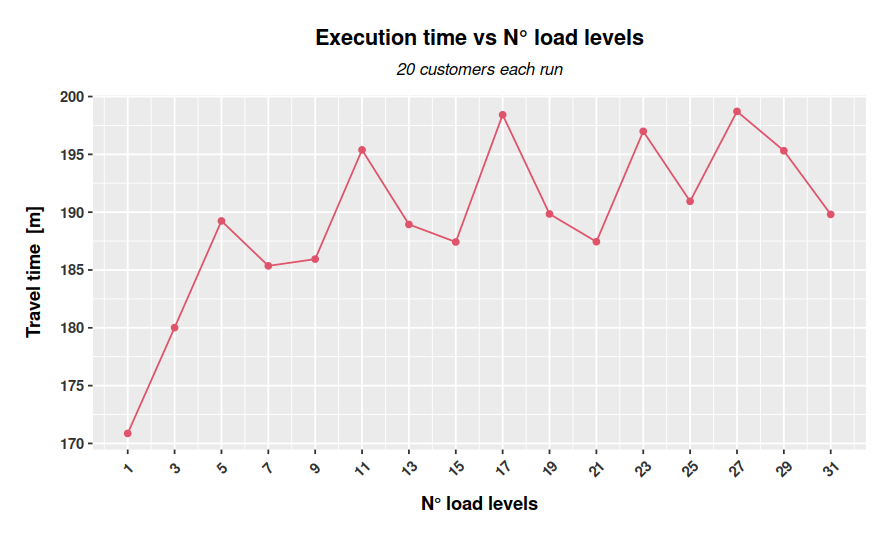

## Numero di livelli di carico - 2

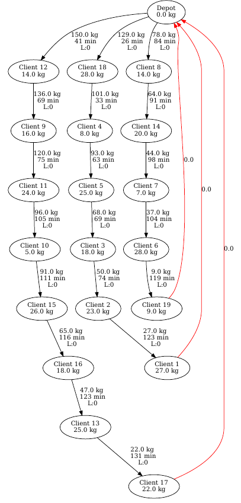

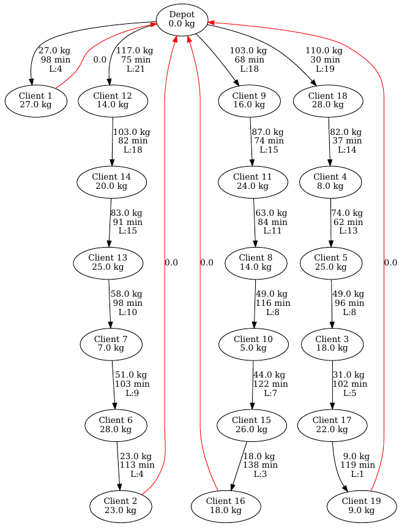

I grafi mostrano i tour nel caso di \(|L|=1\) e \(|L|=31\). Nel caso di un solo livello di carico, l’esempio mostra che all’uscita dal deposito si ha un peso medio superiore, mentre con più livelli di carico viene sfruttato il vantaggio della velocità superiori raggiungibili con un peso del veicolo inferiore.